# Severity Scores: BGD Pilot

REACH BGD

2 July 2019

# Refugees

## Summary

- The index

## Results

Estimated distribution of severity:

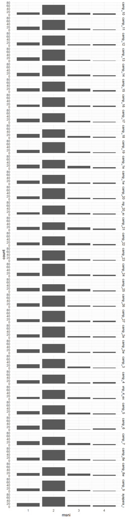

```r
faceted_density_plot(assessment$data,
                     x_variable_name = "msni",
                     default_disaggregation)
```

The estimated severity by location:

```r
type_of_analysis<-map_to_case("group_difference",
                              dependent.var.type = "categorical",
                              independent.var.type = "categorical")

severity_disaggregated <- map_to_result(data,dependent.var = "msni",
                                        independent.var = default_disaggregation,
                                        case = type_of_analysis,
                                        weighting = weighting)





severity_disaggregated %>%
  map_to_labeled(questionnaire) %>%
  map_to_table %>% kable %>% kable_styling()
```

| Subset | 1 | 2 | 3 | 4 |
| --- | --- | --- | --- | --- |
| Camp 10 | 15% (8%-22%) | 64% (55%-74%) | 12% (6%-18%) | 9% (3%-14%) |
| Camp 11 | 22% (14%-30%) | 64% (55%-74%) | 10% (4%-15%) | 4% (0%-8%) |
| Camp 12 | 20% (12%-28%) | 65% (56%-74%) | 7% (2%-12%) | 8% (3%-13%) |
| Camp 13 | 22% (14%-30%) | 70% (62%-79%) | 6% (1%-10%) | 2% (0%-5%) |
| Camp 14 | 20% (12%-27%) | 65% (56%-74%) | 10% (4%-15%) | 5% (1%-10%) |
| Camp 15 | 19% (12%-26%) | 57% (47%-66%) | 17% (10%-23%) | 8% (3%-13%) |
| Camp 16 | 16% (8%-23%) | 66% (56%-75%) | 10% (4%-17%) | 8% (3%-14%) |
| Camp 17 | 25% (16%-34%) | 61% (52%-71%) | 10% (4%-17%) | 3% (0%-7%) |
| Camp 18 | 25% (16%-34%) | 57% (47%-67%) | 11% (5%-18%) | 6% (1%-11%) |
| Camp 19 | 20% (12%-27%) | 67% (58%-76%) | 8% (3%-14%) | 5% (1%-9%) |
| Camp 20 | 17% (10%-24%) | 68% (59%-77%) | 9% (3%-14%) | 7% (2%-11%) |
| Camp 24 | 18% (11%-24%) | 67% (58%-75%) | 9% (4%-14%) | 7% (2%-11%) |
| Camp 25 | 25% (16%-34%) | 51% (41%-61%) | 17% (10%-25%) | 7% (1%-12%) |
| Camp 26 | 21% (13%-29%) | 66% (58%-75%) | 7% (2%-12%) | 5% (1%-10%) |
| Camp 27 | 17% (10%-24%) | 66% (57%-75%) | 9% (4%-14%) | 8% (3%-13%) |
| Camp 3 | 25% (17%-34%) | 60% (50%-69%) | 11% (5%-17%) | 4% (0%-8%) |
| Camp 4 | 22% (14%-30%) | 60% (50%-69%) | 8% (3%-13%) | 10% (4%-16%) |
| Camp 5 | 22% (13%-30%) | 61% (51%-71%) | 11% (5%-18%) | 6% (1%-11%) |
| Camp 6 | 26% (17%-34%) | 65% (56%-74%) | 2% (0%-5%) | 8% (3%-13%) |
| Camp 7 | 26% (18%-35%) | 55% (45%-64%) | 13% (6%-20%) | 6% (1%-11%) |
| Camp 9 | 19% (11%-26%) | 71% (62%-80%) | 7% (2%-12%) | 3% (0%-7%) |
| camp_1e | 24% (16%-32%) | 53% (43%-62%) | 16% (9%-23%) | 8% (3%-13%) |
| camp_1w | 22% (14%-30%) | 60% (51%-70%) | 9% (4%-15%) | 8% (3%-14%) |
| camp_20_extn | 16% (8%-23%) | 66% (56%-76%) | 11% (5%-18%) | 7% (2%-12%) |
| camp_21 | 20% (12%-28%) | 53% (43%-63%) | 18% (10%-26%) | 9% (4%-15%) |
| camp_22 | 18% (11%-26%) | 59% (49%-69%) | 14% (7%-21%) | 8% (3%-14%) |
| camp_23 | 17% (10%-25%) | 68% (59%-78%) | 9% (3%-15%) | 5% (1%-9%) |
| camp_2e | 19% (11%-26%) | 67% (58%-76%) | 8% (3%-14%) | 6% (2%-11%) |
| camp_2w | 25% (16%-34%) | 60% (51%-70%) | 7% (2%-12%) | 7% (2%-12%) |
| camp_4_extn | 15% (7%-22%) | 66% (56%-76%) | 12% (6%-19%) | 7% (2%-12%) |
| camp_8e | 18% (11%-26%) | 70% (61%-79%) | 9% (3%-15%) | 3% (0%-6%) |
| camp_8w | 19% (11%-27%) | 58% (48%-68%) | 16% (8%-23%) | 7% (2%-12%) |
| nayapara_rc | 22% (14%-30%) | 61% (52%-70%) | 10% (4%-15%) | 8% (3%-13%) |

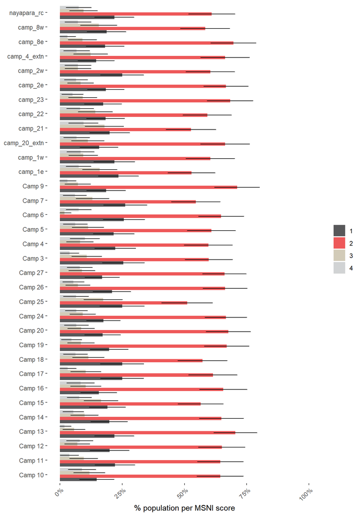

```r
severity_disaggregated %>%
  (function(x){x$summary.statistic<-x$summary.statistic %>% arrange(independent.var.value,numbers);x}) %>%
  map_to_labeled(questionnaire) %>% (hypegrammaR:::grouped_barchart_percent) %>% .$ggplot + coord_flip()+ylab("% population per MSNI score")
```

### Map Severities

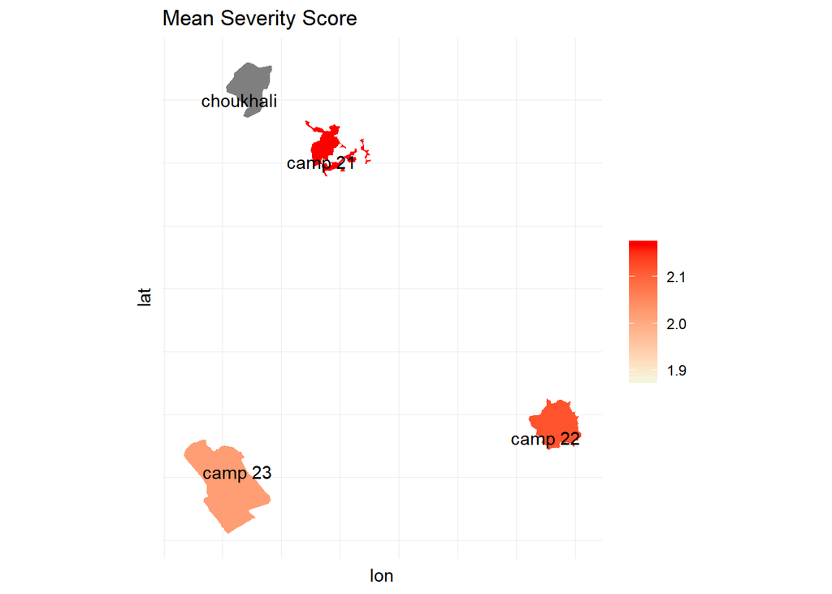

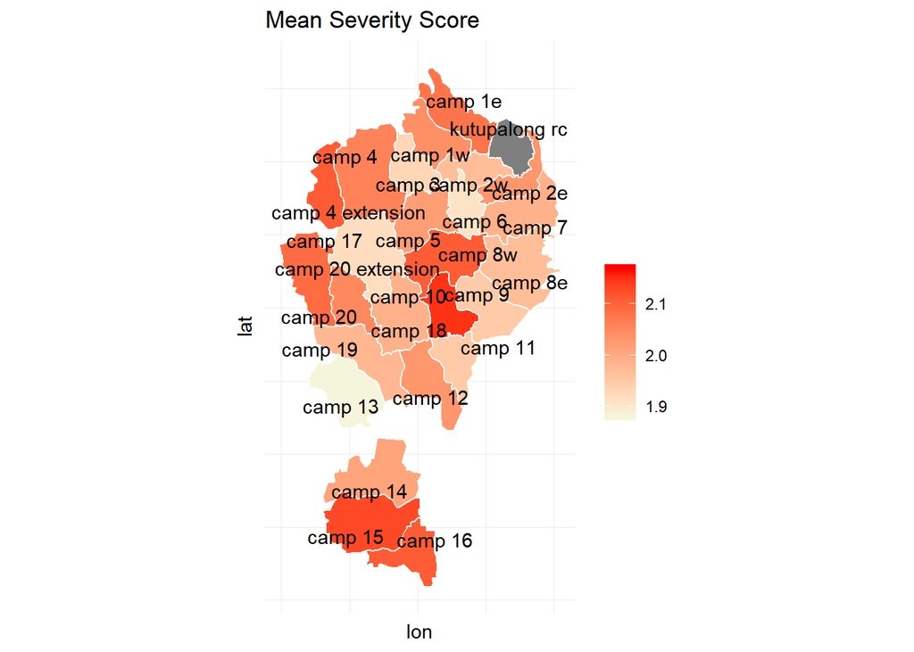

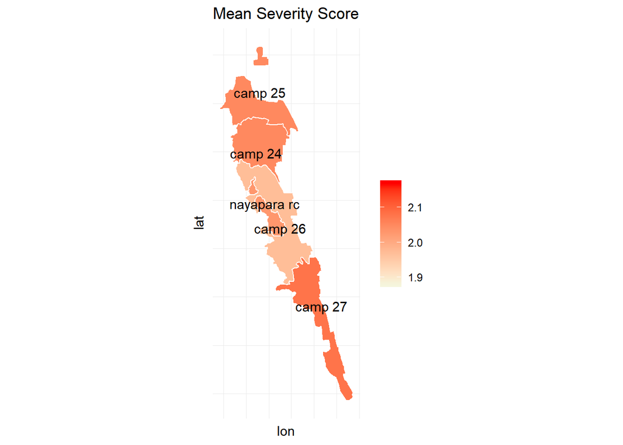

```r
type_of_analysis<-map_to_case("direct_reporting",
                              dependent.var.type = "numerical",
                              independent.var.type = "categorical")

severity_disaggregated <- map_to_result(data,dependent.var = "msni",
                                        independent.var = default_disaggregation,
                                        case = type_of_analysis,
                                        weighting = weighting)



severity_disaggregated %>% result_disaggregated_by_match_id_as_map(assessment)
```

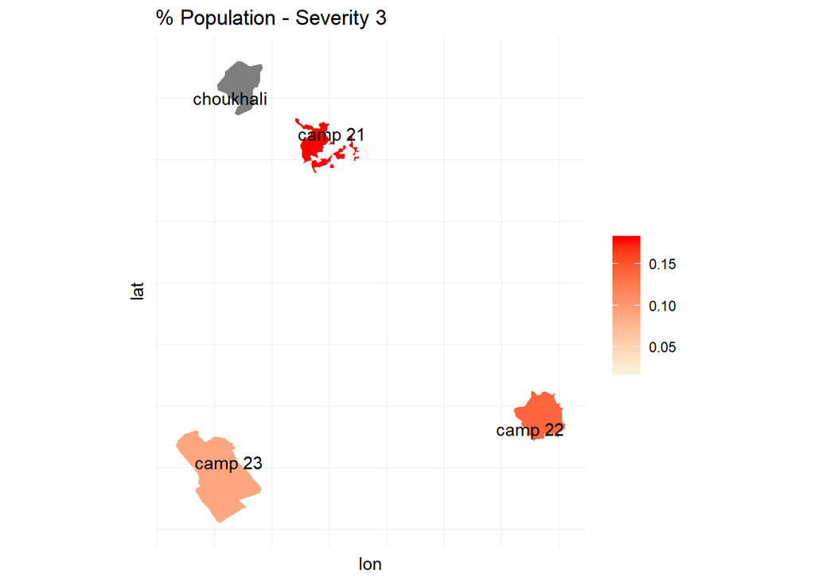

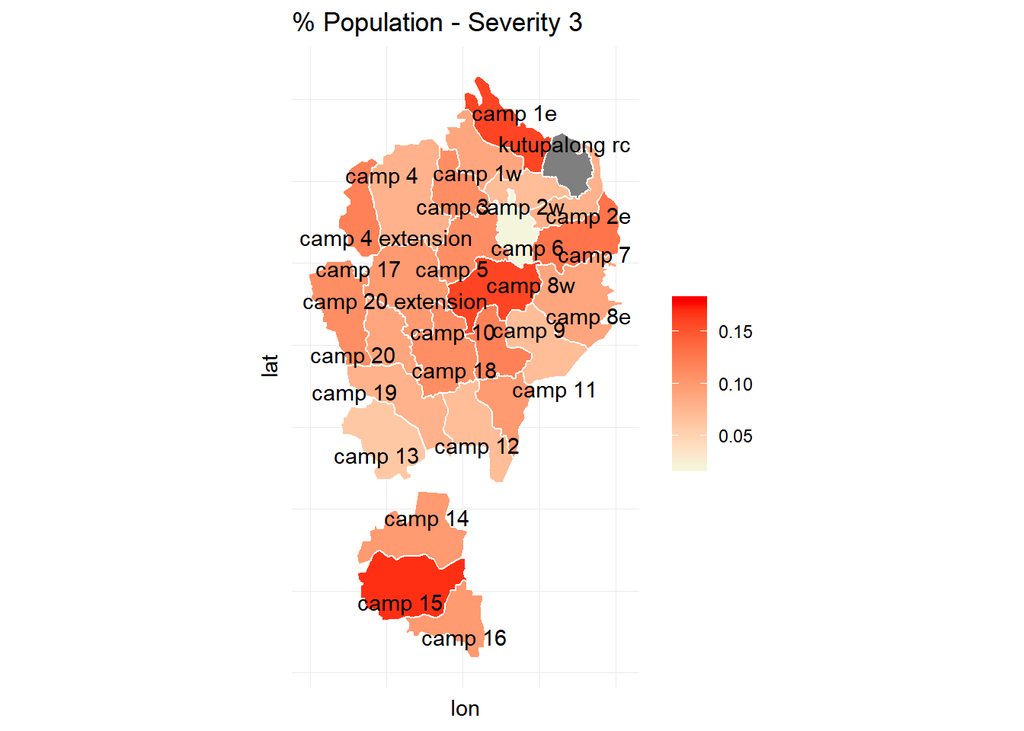

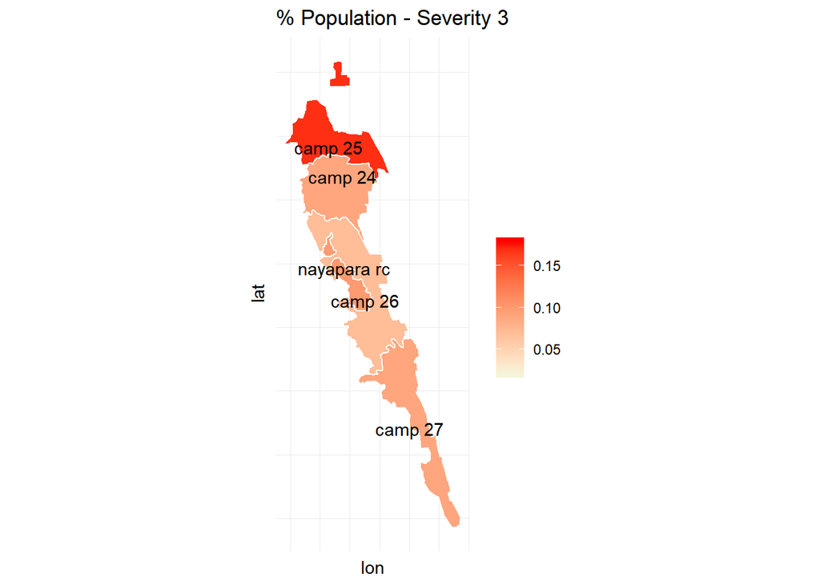

```r
  type_of_analysis<-map_to_case("group_difference",
                                dependent.var.type = "categorical",
                                independent.var.type = "categorical")

  severity_disaggregated4 <- map_to_result(data,dependent.var = "msni",
                                          independent.var = default_disaggregation,
                                          case = type_of_analysis,
                                          weighting = weighting)

  severity_disaggregated3 <- map_to_result(data,dependent.var = "msni",
                                          independent.var = default_disaggregation,
                                          case = type_of_analysis,
                                          weighting = weighting)

  severity_disaggregated3_4 <- map_to_result(data,dependent.var = "msni",
                                          independent.var = default_disaggregation,
                                          case = type_of_analysis,
                                          weighting = weighting)




  severity_disaggregated4$summary.statistic<-severity_disaggregated4$summary.statistic %>%
    filter(as.character(dependent.var.value)=="4")
  severity_disaggregated3$summary.statistic<-severity_disaggregated3$summary.statistic %>%
    filter(as.character(dependent.var.value)=="3")

  severity_disaggregated3_4$summary.statistic<-severity_disaggregated3_4$summary.statistic %>%
    filter(as.character(dependent.var.value)=="3"| as.character(dependent.var.value)=="4") %>%
    group_by(independent.var.value) %>%
    summarise(numbers=sum(numbers))



    # mutate(percent=round(numbers,2)) %>%
    # select(camp_name= independent.var.value,percent)
  #
  severity_disaggregated3 %>% result_disaggregated_by_match_id_as_map(assessment,
                                                                      color_scale_name = "% Population - Severity 3")
```

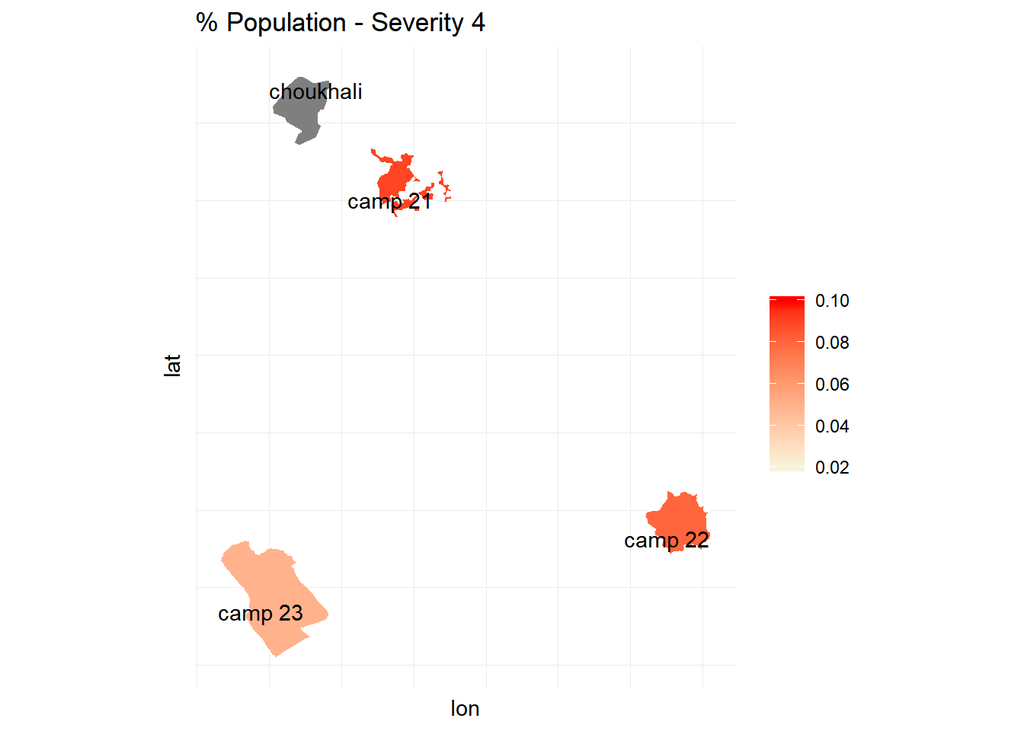

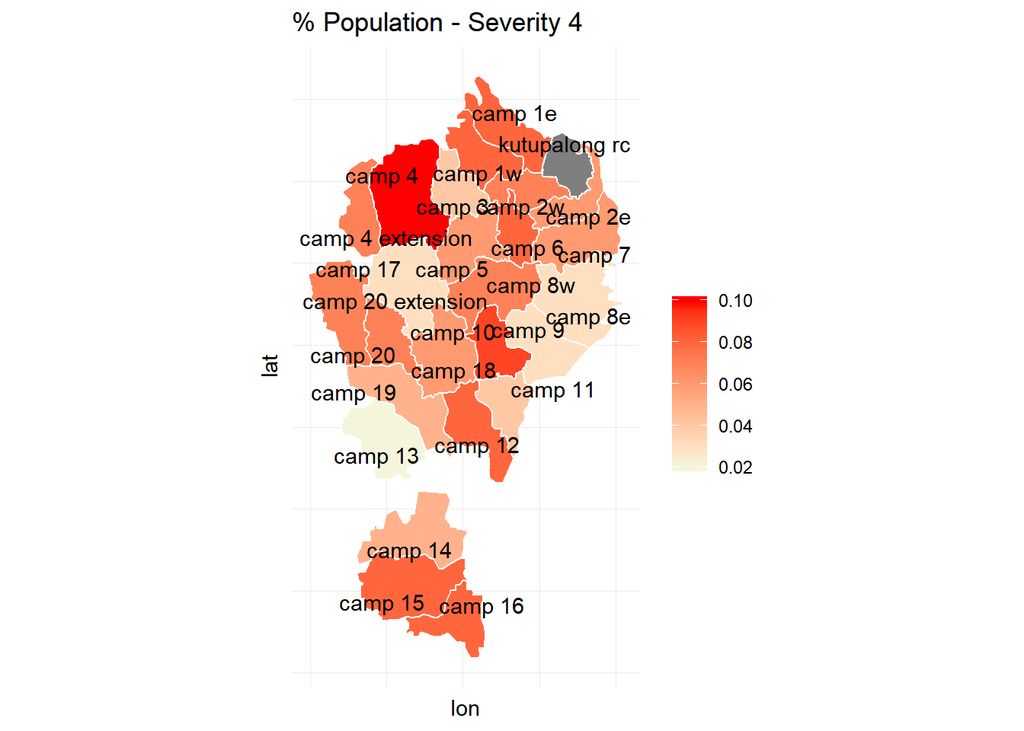

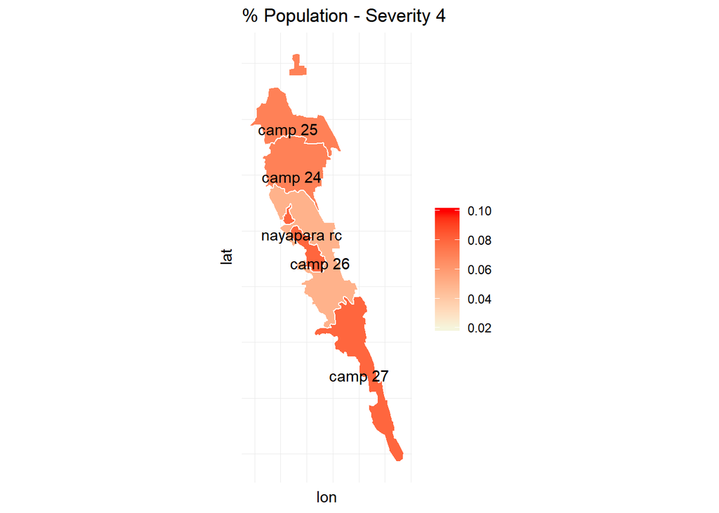

```r
  severity_disaggregated4 %>% result_disaggregated_by_match_id_as_map(assessment,
                                                                      color_scale_name = "% Population - Severity 4")
```

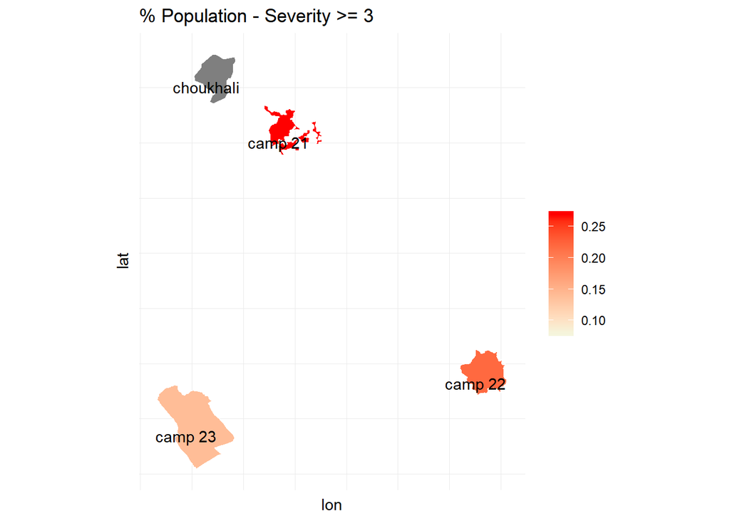

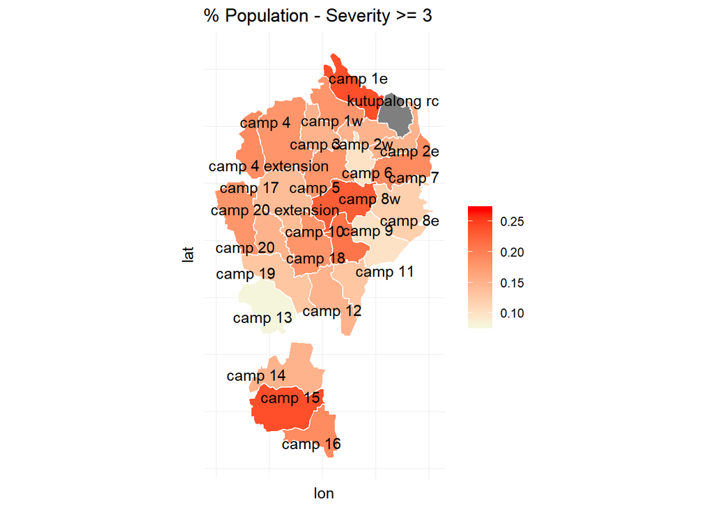

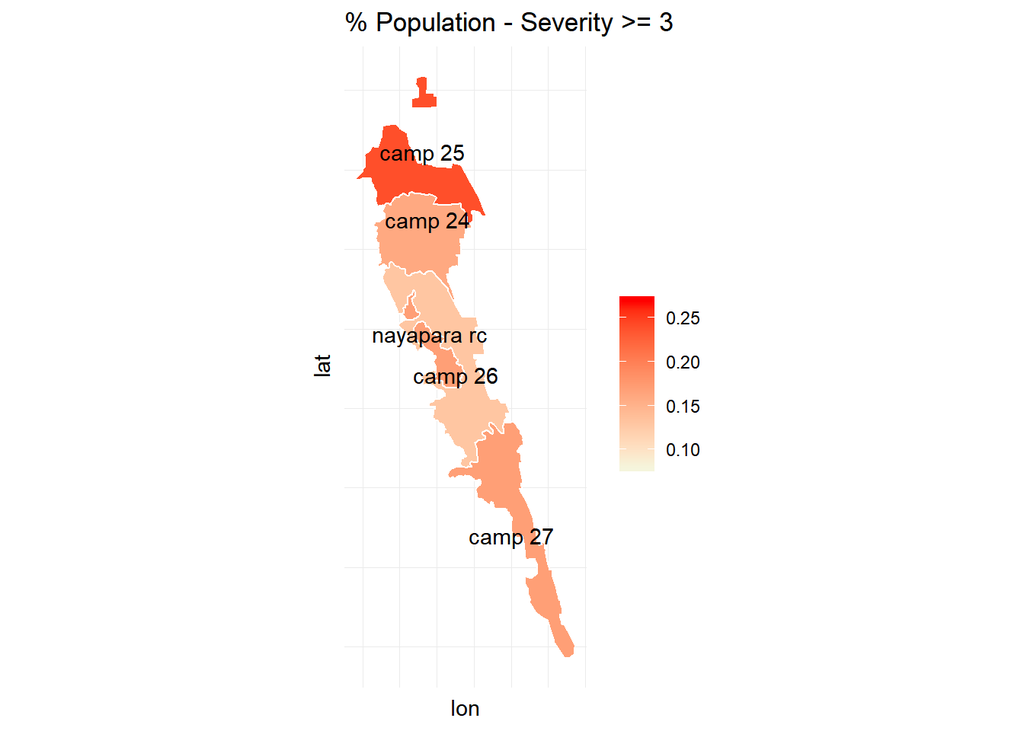

```r
  severity_disaggregated3_4 %>% result_disaggregated_by_match_id_as_map(assessment,
                                                                        color_scale_name = "% Population - Severity >= 3")
```

```r
  # #score of
  # sum_stats<-severity_disaggregated$summary.statistic %>%
  #   filter(as.character(dependent.var.value)=="4") %>%
  #   mutate(percent=round(numbers,2)) %>%
  #   select(camp_name= independent.var.value,percent)
  #
  # sum_stats$camp_name<-str_standardize_cxb_camps(sum_stats$camp_name)
  #
  # sfdf <- st_as_sf(cmp_data)
  #
  # sfdf <- sfdf %>%
  #   mutate(
  #     lon = purrr::map_dbl(geometry, ~ st_centroid(.x)[[1]]),
  #     lat = purrr::map_dbl(geometry, ~ st_centroid(.x)[[2]])
  #   )
  #
  # limits<-c(min(sfdf$percent,na.rm = T),max(sfdf$percent,na.rm = T))
  #
  # plots<-sfdf %>% split(sfdf$camp_setting) %>% purrr::map(function(x){
  #   plot<-ggplot(x)+
  #     geom_sf(aes(fill=percent),color = 'white')+
  #               theme_minimal()+
  #               scale_fill_continuous(limits=limits, name= "Percent Severity Score of 4")+
  #               theme(axis.text.x = element_blank(),
  #                     axis.text.y = element_blank(),
  #                     axis.ticks =element_blank())+
  #               geom_text_repel(aes(x = lon, y = lat, label = camp_name))
  #       print(plot)
  #   })
  #
```

### Distribution - How ‘varied’ are the scores?

```r
design<-map_to_design(data,weighting_function =  weighting)
standard_deviation <- round(sqrt(survey::svyvar(~msni,design,na.rm = T)[1]),2) %>% unname()
```

The overall standard deviation was **0.75**

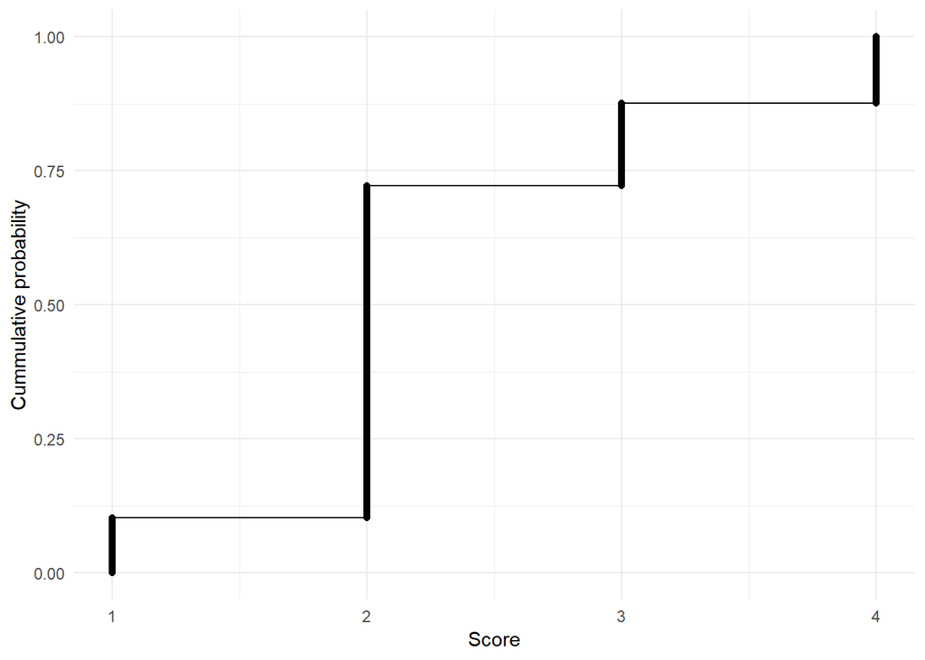

```r
ecdf <- weighted_ecdf(data$msni, weighting(data))

ggplot(ecdf, aes(x, cum.pct)) +
  geom_line() +
  theme_minimal() +
  ylab("Cummulative probability") +
  xlab("Score")+geom_point()
```

```r
#
#
# ggplot(ecdf, aes(x, cum.pct)) +
#   geom_line() +
#   theme_minimal() +
#   ylab("Fraction of sites with more the (x) percent of population with score >=3") +
#   xlab("Score")+geom_point()
```

## Applicability for Prioritisation

In the pilot dataset, the scores generally do not vary enough to identify singificant differences (with p< 0.01) at a disaggregation level sampled for 90% confidence with a 10% error margin. We tested for differences treating the Severity score as numerical and as categorical (nominal)

### Differences between locations (severity numerical)

```r
comparisons <- compare_each(data,
                            dependent.variable = "msni",
                            dependent.variable.type = "numerical",
                            independent.variable = default_disaggregation,
                            weighting = weighting)

kable_comparison_result(comparisons,independent.variable.title =  "Location")
```

| Location | Obverved | Observed (all other) | p Value (Bonferroni corrected) | Difference | Significant (at p < 0.01) |
| --- | --- | --- | --- | --- | --- |
| Camp 13 | 1.876191 | 2.027532 | 0.2297728 | 0.1513418 | No |
| Camp 6 | 1.914286 | 2.023409 | 3.8511321 | 0.1091230 | No |
| Camp 17 | 1.916667 | 2.022223 | 3.5339315 | 0.1055559 | No |
| Camp 3 | 1.931372 | 2.024478 | 5.4837924 | 0.0931056 | No |
| Camp 9 | 1.948454 | 2.023514 | 6.5171463 | 0.0750608 | No |
| Camp 11 | 1.951923 | 2.022797 | 8.2102362 | 0.0708741 | No |
| camp_2w | 1.968750 | 2.021825 | 14.7994838 | 0.0530753 | No |
| camp_8e | 1.969697 | 2.022211 | 11.4655932 | 0.0525142 | No |
| Camp 26 | 1.972727 | 2.022663 | 13.2581329 | 0.0499361 | No |
| Camp 19 | 1.981132 | 2.021271 | 15.5987689 | 0.0401388 | No |
| Camp 7 | 1.989899 | 2.021759 | 20.6321501 | 0.0318600 | No |
| Camp 18 | 1.989583 | 2.021361 | 20.5266041 | 0.0317777 | No |
| Camp 14 | 2.009009 | 2.020713 | 25.4783175 | 0.0117038 | No |
| camp_23 | 2.020408 | 2.020311 | 29.9229859 | -0.0000975 | No |
| Camp 5 | 2.020619 | 2.020303 | 30.3022478 | -0.0003160 | No |
| camp_2e | 2.027778 | 2.020046 | 32.7551967 | -0.0077323 | No |
| nayapara_rc | 2.028571 | 2.020070 | 32.9462990 | -0.0085011 | No |
| Camp 12 | 2.030000 | 2.020070 | 32.4486593 | -0.0099296 | No |
| camp_1w | 2.041667 | 2.019274 | 28.6910925 | -0.0223923 | No |
| Camp 20 | 2.047619 | 2.020075 | 25.8140736 | -0.0275441 | No |
| Camp 24 | 2.050000 | 2.019117 | 24.4658703 | -0.0308829 | No |
| Camp 25 | 2.054348 | 2.019939 | 25.0641652 | -0.0344084 | No |
| Camp 4 | 2.060606 | 2.018748 | 23.0166092 | -0.0418577 | No |
| camp_1e | 2.075472 | 2.017709 | 18.2485073 | -0.0577631 | No |
| Camp 27 | 2.080357 | 2.019352 | 15.1957067 | -0.0610050 | No |
| camp_20_extn | 2.089888 | 2.019973 | 13.8771128 | -0.0699141 | No |
| camp_4_extn | 2.112360 | 2.019832 | 8.8886558 | -0.0925276 | No |
| Camp 16 | 2.114583 | 2.017994 | 8.6089712 | -0.0965898 | No |
| camp_8w | 2.114583 | 2.016660 | 9.1410448 | -0.0979236 | No |
| camp_22 | 2.122449 | 2.017936 | 7.7953915 | -0.1045129 | No |
| Camp 15 | 2.130435 | 2.013850 | 5.5198950 | -0.1165847 | No |
| Camp 10 | 2.148515 | 2.015307 | 3.7587267 | -0.1332081 | No |
| camp_21 | 2.168421 | 2.018066 | 3.4335191 | -0.1503547 | No |

### Differences between locations (severity categorical)

```r
comparisons <- compare_each(data,
                            dependent.variable = "msni",
                            dependent.variable.type = "categorical",
                            independent.variable = default_disaggregation,
                            weighting = weighting)

comparisons %>% kable_comparison_result_categorical("Location")
```

| Location | p Value | percentage points difference to others 1 | percentage points difference to others 2 | percentage points difference to others 3 | percentage points difference to others 4 | P Value (Bonferroni corrected) | Significant (at p < 0.01) |
| --- | --- | --- | --- | --- | --- | --- | --- |
| Camp 27 | 0.660394 | -0.0358663 | 0.5561027 | -0.1162234 | -0.0242544 | 21.793 | No |

### Differences based on Vulnerability Indicators

```r
for(i in names(vulnerability)){
  data[[i]]<-vulnerability[[i]]
}

vulnerability_columns<-names(data) %>% grep("^vi\\.",.,value = T)
vulnerability_columns<- vulnerability_columns[-1]

for(vi in vulnerability_columns){

  cat(paste0("\n\n**",vi,"**\n\n"))
  if(length(unique(data[[vi]]))>1){
    comparisons <- compare_each(data,
                                dependent.variable = "msni",
                                dependent.variable.type = "categorical",
                                independent.variable = vi,
                                weighting = weighting)

    comparisons %>% kable_comparison_result_categorical(vi) %>% cat
  }
}
```

**vi.over60**

| vi.over60 | p Value | percentage points difference to others 1 | percentage points difference to others 2 | percentage points difference to others 3 | percentage points difference to others 4 | P Value (Bonferroni corrected) | Significant (at p < 0.01) |
| --- | --- | --- | --- | --- | --- | --- | --- |
| 0 | 0.0500955 | 0.1212836 | 0.0280281 | 0.0148022 | -0.5435531 | 0.1001909 | No |

**vi.preg_lact**

| vi.preg_lact | p Value | percentage points difference to others 1 | percentage points difference to others 2 | percentage points difference to others 3 | percentage points difference to others 4 | P Value (Bonferroni corrected) | Significant (at p < 0.01) |
| --- | --- | --- | --- | --- | --- | --- | --- |
| 0 | 0.3111627 | 0.1408847 | 0.0328656 | 0.0384013 | -0.5344656 | 0.6223254 | No |

**vi.female_hoh**

| vi.female_hoh | p Value | percentage points difference to others 1 | percentage points difference to others 2 | percentage points difference to others 3 | percentage points difference to others 4 | P Value (Bonferroni corrected) | Significant (at p < 0.01) |
| --- | --- | --- | --- | --- | --- | --- | --- |
| 1 | 0.0002084 | 0.1172921 | -0.0180192 | 0.07236 | -0.5530244 | 0.0004168 | Yes |

**vi.hh_size**

| vi.hh_size | p Value | percentage points difference to others 1 | percentage points difference to others 2 | percentage points difference to others 3 | percentage points difference to others 4 | P Value (Bonferroni corrected) | Significant (at p < 0.01) |
| --- | --- | --- | --- | --- | --- | --- | --- |
| 0 | 0 | 0.1793209 | -0.1266967 | 0.009874 | -0.6587423 | 0 | Yes |

## Sensitivity and Robustness

### Missing values in composite indicators

```r
percent_na_sev<-severity[,-1] %>% lapply(percent_na) %>% unlist
data.frame(`composite variable` = names(severity[,-1]),
           `percent NA` = percent_na_sev,
           check.names = FALSE) %>%
  kable %>%
  kable_styling()
```

|  | composite variable | percent NA |
| --- | --- | --- |
| si.edu.learning_space_attendance | si.edu.learning_space_attendance | 0 % |
| si.edu.non_religious_learning | si.edu.non_religious_learning | 0 % |
| si.health.mosquito_net | si.health.mosquito_net | 0 % |
| si.health.illness.serious | si.health.illness.serious | 0 % |
| si.health.dia_ors | si.health.dia_ors | 0 % |
| si.capacity_gap.child_lab_bad | si.capacity_gap.child_lab_bad | 0 % |
| si.fsl | si.fsl | 0 % |
| si.protection.lighting | si.protection.lighting | 0 % |
| si.protection.unsafe | si.protection.unsafe | 0 % |
| si.shelter.shelt_damage | si.shelter.shelt_damage | 0 % |
| si.shelter.essential | si.shelter.essential | 0 % |
| si.wash.defec | si.wash.defec | 0 % |
| si.wash.drnk_dom_water | si.wash.drnk_dom_water | 0 % |
| si.wash.garbage_disp | si.wash.garbage_disp | 0 % |
| si.wash.improved_water | si.wash.improved_water | 0 % |
| si.capacity_gap.child_marriage_reduce_burden | si.capacity_gap.child_marriage_reduce_burden | 0 % |
| si.capacity_gap.debt | si.capacity_gap.debt | 0 % |
| si.health.preg | si.health.preg | 0 % |
| capacity | capacity | 0 % |
| capacity_gap | capacity_gap | 0 % |
| edu | edu | 0 % |
| fsl | fsl | 0 % |
| health | health | 0 % |
| ios | ios | 0 % |
| protection | protection | 0 % |
| shelter | shelter | 0 % |
| wash | wash | 0 % |
| impact | impact | 0 % |

### Sensitivity to Included Indicators

```r
# create variations and calculate msni

msni_varied_indicators<-msni_variations(combination_tables,
                                        assessment$severity,
                                        variation_function = vary_combination_tables_indicator_inclusion)
```

```r
cat(if(group == "refugee"){

  "We show that overall, the index is not overly affected by removing (and by extension adding) individual indicators from the calculation, with the exception of three indicators whos importance warrants a stronger impact."

} else if( group == "host"){

  "We show that overall, the index is not overly affected by removing (and by extension adding) individual indicators from the calculation."


}
)
```

We show that overall, the index is not overly affected by removing (and by extension adding) individual indicators from the calculation, with the exception of three indicators whos importance warrants a stronger impact.

```r
cat(paste("We test how sensitive the index is with regards to which indicators are included; The overall score should ideally not be completely changed if specific indicators are added or removed; at the same time we should expect at least some variation based on which indicators are included. Prior to analysis, we choose a threshold of **a difference of 0.5 on the 1-4 scale that should ideally not be surpassed** if an individual indicator is removed (or added). We recalculate the score after removing each of the",ncol(msni_varied_indicators),"sub-indicators , and test for each one whether the difference to the complete index exceeds 0.5"))
```

We test how sensitive the index is with regards to which indicators are included; The overall score should ideally not be completely changed if specific indicators are added or removed; at the same time we should expect at least some variation based on which indicators are included. Prior to analysis, we choose a threshold of **a difference of 0.5 on the 1-4 scale that should ideally not be surpassed** if an individual indicator is removed (or added). We recalculate the score after removing each of the 23 sub-indicators , and test for each one whether the difference to the complete index exceeds 0.5

```r
# t-test: differences smaller 0.5 on average?

# new dataframe: differences & stratum

msni_original<- tibble(msni = assessment$data$msni)


sensitivity_test_table<- sensitivity_variation_test_result_table(msni_original = msni_original,
                                                                 msni_varied = msni_varied_indicators,
                                                                 threshold = 0.5,
                                                                 strata_data_name = default_disaggregation,
                                                                 strata_data_values = data[[default_disaggregation]])

sensitivity_test_table %>% kable(escape = FALSE) %>% kable_styling()
```

| Indicator | average absolute difference from original msni index | p value (Bonferroni corrected) | Difference signifcantly smaller than threshold (at p<=0.01) |
| --- | --- | --- | --- |
| wash improved_water | 0.7550863 | 0.0000 | No |
| capacity_gap child_marriage_reduce_burden | 0.7493915 | 0.0000 | No |
| wash drnk_dom_water | 0.4992004 | 21.3041 | No |
| capacity_gap child_lab_bad | 0.3305647 | 0.0000 | Yes |
| health preg | 0.2311596 | 0.0000 | Yes |
| shelter shelt_damage | 0.1895356 | 0.0000 | Yes |
| capacity_gap debt | 0.1658999 | 0.0000 | Yes |
| health illness serious | 0.1416174 | 0.0000 | Yes |
| health dia_ors | 0.1254802 | 0.0000 | Yes |
| shelter essential | 0.0842962 | 0.0000 | Yes |
| wash defec | 0.0805218 | 0.0000 | Yes |
| protection lighting | 0.0498006 | 0.0000 | Yes |
| protection unsafe | 0.0309778 | 0.0000 | Yes |
| health mosquito_net | 0.0302106 | 0.0000 | Yes |
| edu learning_space_attendance | 0.0152898 | 0.0000 | Yes |
| edu non_religious_learning | 0.0152898 | 0.0000 | Yes |
| V4 | 0.0000000 | 0.0000 | Yes |
| V5 | 0.0000000 | 0.0000 | Yes |
| V6 | 0.0000000 | 0.0000 | Yes |
| V13 | 0.0000000 | 0.0000 | Yes |
| V14 | 0.0000000 | 0.0000 | Yes |
| V15 | 0.0000000 | 0.0000 | Yes |
| wash garbage_disp | 0.0000000 | 0.0000 | Yes |

```r
cat(if(group == "refugee"){

  "The overall index changes more than 0.5 points when removing the indicators for _drinking water source_ (WASH), _child marriage to reduce economic burden_ (Capacity Gaps) and _water access quantity_ (WASH). In the composite index, these indicators were consiously selected to have strong impact. As such, it is expected that their removal would have a strong impact on the results.

The index is robust towards all other indicators within the threshold of 0.5 points on the scale."

} else if( group == "host"){


  "None of the indicators led to a change of more than 0.5 in the average score when removed. This suggests that the index is robust towards inclusion / exclusion of indicators"


}
)
```

The overall index changes more than 0.5 points when removing the indicators for *drinking water source* (WASH), *child marriage to reduce economic burden* (Capacity Gaps) and *water access quantity* (WASH). In the composite index, these indicators were consiously selected to have strong impact. As such, it is expected that their removal would have a strong impact on the results.

The index is robust towards all other indicators within the threshold of 0.5 points on the scale.

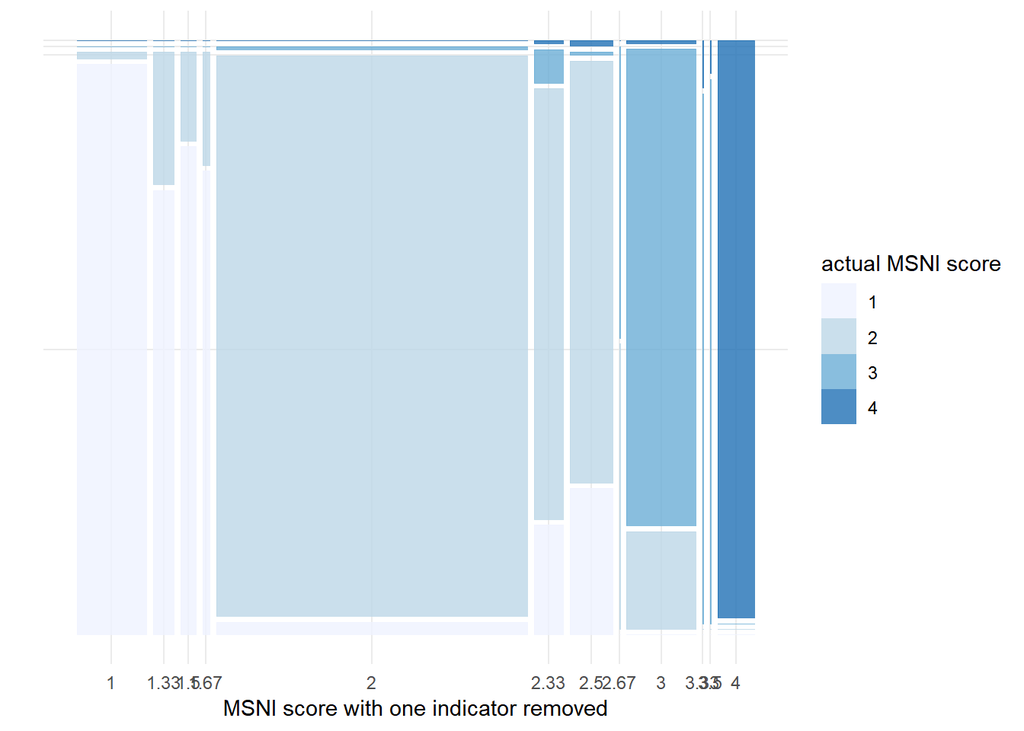

```r
# Example of how the formula is built
#
#     weight = 1
#     x = product(Y, X)
#     fill = W
#     conds = product(Z)
#
# These aesthetics set up the formula for the distribution:
#
#     Formula: 1 ~ W + X + Y | Z

stratum_tibble<-tibble(stratum=assessment$data[[default_disaggregation]])
colnames(stratum_tibble)<-default_disaggregation
msni_varied_and_original<-c(msni_varied_indicators,
                            msni_original,
                            stratum_tibble) %>% as_tibble

msni_varied_and_original<-gather_(msni_varied_and_original,key = "key",value = 'value',gather_cols = names(msni_varied_and_original)[!(names(msni_varied_and_original) %in% c("msni",default_disaggregation))])
msni_varied_and_original$weights<-weighting(msni_varied_and_original)
msni_varied_and_original$value<-round(msni_varied_and_original$value,2)
msni_varied_and_original<-msni_varied_and_original[!is.na(msni_varied_and_original),]
ggplot(msni_varied_and_original)+
  geom_mosaic(aes(weight=weights,
                  x=product(msni,value),fill = (msni)))+scale_fill_brewer(name = "actual MSNI score")+theme_minimal()+theme(axis.text.y = element_blank())+xlab("MSNI score with one indicator removed")+ylab("")
```

### Sensitivity to Thresholds

The methodology relies heavily on normative judgement from sector as well is inter-sectoral experts. As such, it needs to be robust with regards to variations in those judgements. We add random noise of varying strength to the expert decision of how the indicators are combined, and compare the results to the original msni needs score.

```r
# create variations and calculate msni
msni_varied_thresholds<-msni_variations(combination_tables,
                                        assessment$severity,
                                        variation_function = vary_combination_tables_thresholds)
```

```r
# t-test: differences smaller 0.5 on average?

# new dataframe: differences & stratum

msni_original<- tibble(msni = assessment$data$msni)


sensitivity_test_table<- sensitivity_variation_test_result_table(msni_original = msni_original,
                                                                 msni_varied = msni_varied_thresholds,
                                                                 threshold = 0.5,
                                                                 strata_data_name = default_disaggregation,
                                                                 strata_data_values = data[[default_disaggregation]])

sensitivity_test_table %>% kable(escape = FALSE) %>% kable_styling()
```

| Indicator | average absolute difference from original msni index | p value (Bonferroni corrected) | Difference signifcantly smaller than threshold (at p<=0.01) |
| --- | --- | --- | --- |
| V42 | 0.5889316 | 0.00000 | No |
| V46 | 0.5889316 | 0.00000 | No |
| V47 | 0.5889316 | 0.00000 | No |
| V83 | 0.4551730 | 0.00015 | Yes |
| V84 | 0.4551730 | 0.00015 | Yes |
| V87 | 0.4551730 | 0.00015 | Yes |
| V88 | 0.4551730 | 0.00015 | Yes |
| V89 | 0.4551730 | 0.00015 | Yes |
| V90 | 0.4551730 | 0.00015 | Yes |
| shelter | 0.4078310 | 0.00000 | Yes |
| V72 | 0.4078310 | 0.00000 | Yes |
| V74 | 0.4078310 | 0.00000 | Yes |
| V77 | 0.4078310 | 0.00000 | Yes |
| V2 | 0.4004129 | 0.00000 | Yes |
| V4 | 0.4004129 | 0.00000 | Yes |
| V5 | 0.4004129 | 0.00000 | Yes |
| V10 | 0.4004129 | 0.00000 | Yes |
| V63 | 0.3022659 | 0.00000 | Yes |
| V66 | 0.3022659 | 0.00000 | Yes |
| V67 | 0.3022659 | 0.00000 | Yes |
| fsl | 0.2243888 | 0.00000 | Yes |
| V34 | 0.2243888 | 0.00000 | Yes |
| V40 | 0.2243888 | 0.00000 | Yes |
| health | 0.1426526 | 0.00000 | Yes |
| V43 | 0.1426526 | 0.00000 | Yes |
| V44 | 0.1426526 | 0.00000 | Yes |
| V45 | 0.1426526 | 0.00000 | Yes |
| V48 | 0.1426526 | 0.00000 | Yes |
| V49 | 0.1426526 | 0.00000 | Yes |
| V50 | 0.1426526 | 0.00000 | Yes |

[output cut: 60 more lines]

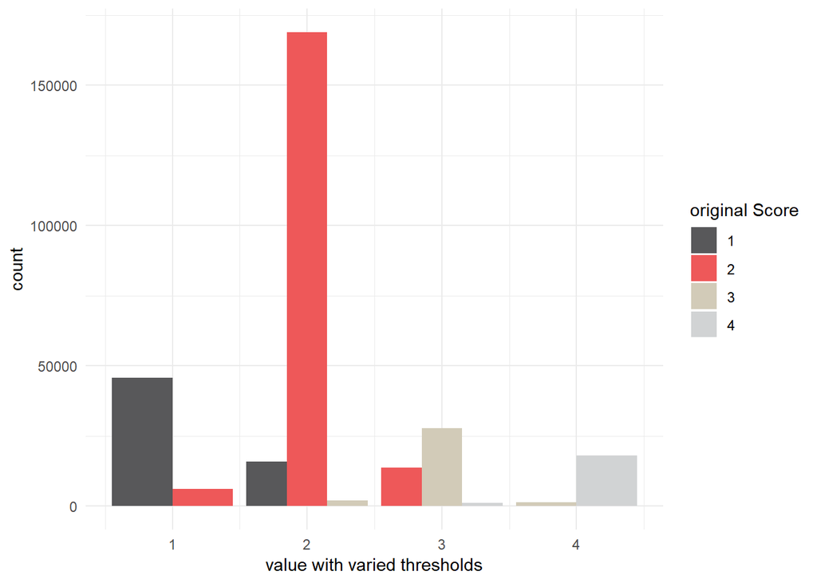

```r
msni_varied_thresholds_with_original<-msni_varied_thresholds
msni_varied_thresholds_with_original$original<-assessment$data$msni

msni_varied_thresholds_long <- msni_varied_thresholds_with_original %>% gather("key","value", -original)
msni_varied_thresholds_long$key<-gsub("\\.","",msni_varied_thresholds_long$key) %>% gsub("[0-9]","",.)
ggplot(msni_varied_thresholds_long)+geom_bar(aes(x = value,fill = factor(original)),position = "dodge")+xlab("value with varied thresholds")+hypegrammaR:::scale_fill_reach_categorical(4,name = "original Score")+theme_minimal()
```

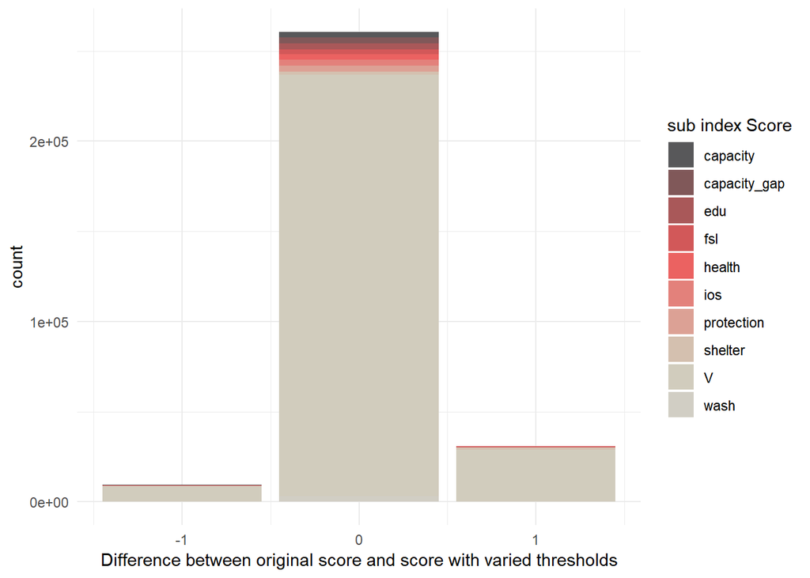

```r
diffs<-lapply(msni_varied_thresholds_with_original,function(x){x-unlist(msni_original)}) %>% as_tibble %>% gather("key","value",-original)
diffs$key<-gsub("\\.","",msni_varied_thresholds_long$key) %>% gsub("[0-9]","",.)
ggplot(diffs)+geom_bar(aes(x=value,fill=key))+hypegrammaR:::scale_fill_reach_categorical(12,name = "sub index Score")+theme_minimal()+xlab("Difference between original score and score with varied thresholds")
```

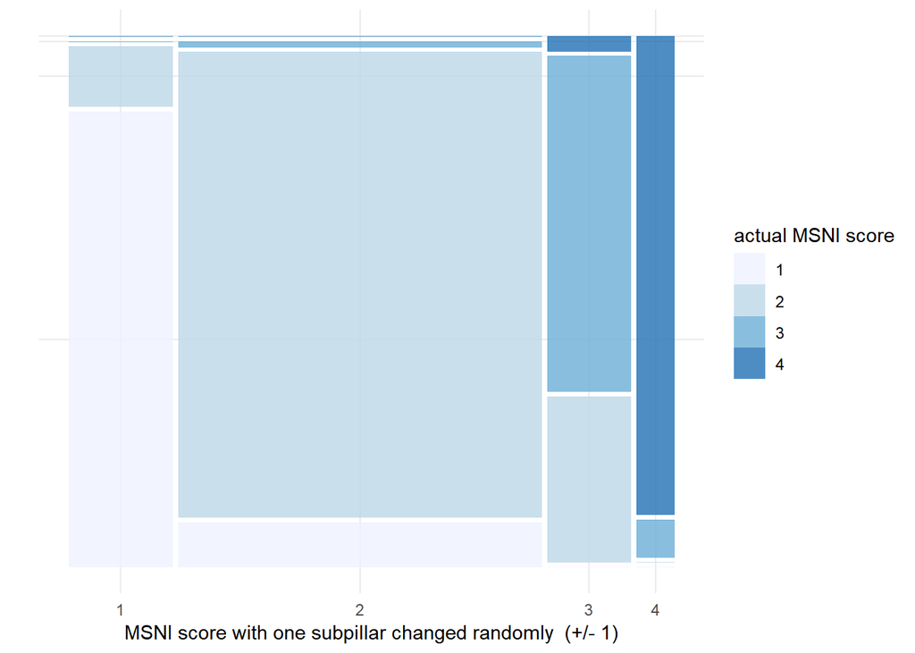

```r
# Example of how the formula is built
#
#     weight = 1
#     x = product(Y, X)
#     fill = W
#     conds = product(Z)
#
# These aesthetics set up the formula for the distribution:
#
#     Formula: 1 ~ W + X + Y | Z

stratum_tibble<-tibble(stratum=assessment$data[[default_disaggregation]])
colnames(stratum_tibble)<-default_disaggregation
msni_varied_and_original<-c(msni_varied_thresholds,
                            msni_original,
                            stratum_tibble) %>% as_tibble

msni_varied_and_original<-gather_(msni_varied_and_original,key = "key",value = 'value',gather_cols = names(msni_varied_and_original)[!(names(msni_varied_and_original) %in% c("msni",default_disaggregation))])
msni_varied_and_original$weights<-weighting(msni_varied_and_original)
msni_varied_and_original$value<-round(msni_varied_and_original$value,2)
msni_varied_and_original<-msni_varied_and_original[!is.na(msni_varied_and_original),]
ggplot(msni_varied_and_original)+
  geom_mosaic(aes(weight=weights,
                  x=product(msni,value),fill = (msni)))+scale_fill_brewer(name = "actual MSNI score")+theme_minimal()+theme(axis.text.y = element_blank())+xlab("MSNI score with one subpillar changed randomly  (+/- 1)")+ylab("")
```

```r
assessment$vulnerability<-host_vulnerability_bgd_msna18(assessment$data,
                                                        assessment$loops$individuals)

#
# assessment$vulnerability<-refugee_vulnerability_bgd_msna18(assessment$data,
#                                  assessment$loops$individuals)
#
# data_w_vulnerability<-c(data,assessment$vulnerability) %>% as.data.frame(stringsAsFactors = FALSE)
#
# data_w_vulnerability<-data_w_vulnerability[data_w_vulnerability$msni>=3,]
#
# vars_for_factor_analysis<-data_w_vulnerability %>% names %>% grep("^vi.",.,value = TRUE) #
#
# data_w_vulnerability <- data_w_vulnerability[complete.cases(data_w_vulnerability[,c(vars_for_factor_analysis,default_disaggregation)]),]
#
# data_w_vulnerability[,vars_for_factor_analysis]<-lapply(data_w_vulnerability[,vars_for_factor_analysis],as.numeric) %>% as.data.frame(stringsAsFactors=F)
#
# design<-map_to_design(data_w_vulnerability %>% as.data.frame,weighting_function = weighting)
#
# formula<-vars_for_factor_analysis[-1] %>% paste0(.,collapse = "+") %>% paste0("~",.) %>% formula()
#
# library(FactoMineR)
# FactoMineR::MFA(data_w_vulnerability[,vars_for_factor_analysis],)
#
# fact<-factanal(formula,
#             design = data_w_vulnerability,
#             factors = 1)
#
# library(factoextra)
#
# print(fit, digits=2, cutoff=.3, sort=TRUE)
# # plot factor 1 by factor 2
# load <- fit$loadings[,1:2]
# plot(load,type="n") # set up plot
# text(load,labels=names(mydata),cex=.7) # add variable names
```